# Set Environment

```python
import numpy as np
import pandas as pd
import seaborn as sns
import matplotlib.pyplot as plt
```

```python
df=pd.read_csv('/Users/warren/Desktop/UTD/19 Summer break/project/Mall Customer Segmentation Data ( Kmeans Using Py)/Mall_Customers.csv')
```

```python
df.info()
```

```
<class 'pandas.core.frame.DataFrame'>
RangeIndex: 200 entries, 0 to 199
Data columns (total 5 columns):
CustomerID                200 non-null int64
Gender                    200 non-null object
Age                       200 non-null int64
Annual Income (k$)        200 non-null int64
Spending Score (1-100)    200 non-null int64
dtypes: int64(4), object(1)
memory usage: 7.9+ KB
```

```python
df.head()
```

|  | CustomerID | Gender | Age | Annual Income (k$) | Spending Score (1-100) |
| --- | --- | --- | --- | --- | --- |
| 0 | 1 | Male | 19 | 15 | 39 |
| 1 | 2 | Male | 21 | 15 | 81 |
| 2 | 3 | Female | 20 | 16 | 6 |
| 3 | 4 | Female | 23 | 16 | 77 |
| 4 | 5 | Female | 31 | 17 | 40 |

```python
#Row and Column
df.shape
```

```
(200, 5)
```

```python
#Null Check
df.isnull().sum()
```

```
CustomerID                0
Gender                    0
Age                       0
Annual Income (k$)        0
Spending Score (1-100)    0
dtype: int64
```

```python
#Summary
df.describe().T.drop('count',axis=1)
```

|  | mean | std | min | 25% | 50% | 75% | max |
| --- | --- | --- | --- | --- | --- | --- | --- |
| CustomerID | 100.50 | 57.879185 | 1.0 | 50.75 | 100.5 | 150.25 | 200.0 |
| Age | 38.85 | 13.969007 | 18.0 | 28.75 | 36.0 | 49.00 | 70.0 |
| Annual Income (k$) | 60.56 | 26.264721 | 15.0 | 41.50 | 61.5 | 78.00 | 137.0 |
| Spending Score (1-100) | 50.20 | 25.823522 | 1.0 | 34.75 | 50.0 | 73.00 | 99.0 |

```python
print('Mean of Annual Income(k$) of Female: {}'.format(df['Annual Income (k$)'].loc[df['Gender']=='Female'].mean()))
print('Mean of Annual Income(k$) of Male: {}'.format(round(df['Annual Income (k$)'].loc[df['Gender']=='Male'].mean(),2)))
```

```
Mean of Annual Income(k$) of Female: 59.25
Mean of Annual Income(k$) of Male: 62.23
```

```python
print("Mean of Spending Score (1-100) of Female: {}".format(round(df['Spending Score (1-100)'].loc[df.Gender=='Female'].mean(),2)))
print("Mean of Spending Score (1-100) of Male: {}".format(round(df['Spending Score (1-100)'].loc[df.Gender=='Male'].mean(),2)))
```

```
Mean of Spending Score (1-100) of Female: 51.53
Mean of Spending Score (1-100) of Male: 48.51
```

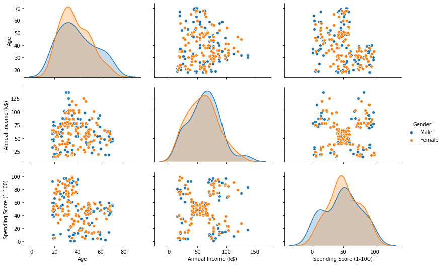

```python
x= df.drop(['CustomerID'],axis=1)
sns.pairplot(x, hue='Gender', aspect= 1.5)
plt.show()
```

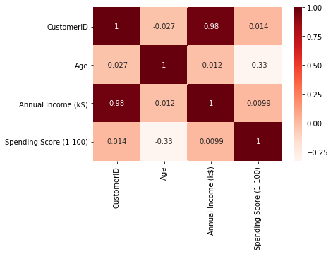

```python
sns.heatmap(df.corr(), annot=True, cmap= 'Reds')
plt.show()
```

```python
#df.query('Gender == "Male"').Gender.count()
df.Gender.value_counts()
```

```
Female    112
Male       88
Name: Gender, dtype: int64
```

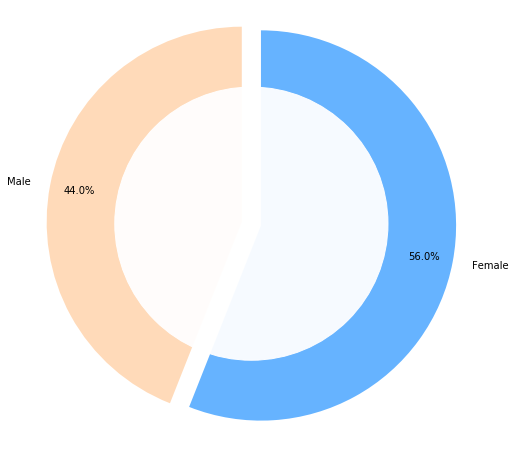

```python
labels = ['Male','Female']
sizes = [df.query('Gender == "Male"').Gender.count(),df.query('Gender == "Female"').Gender.count()]
#colors
colors = ['#ffdaB9','#66b3ff']
#explsion
explode = (0.05,0.05)
####how far two piece spread
plt.figure(figsize=(8,8))
my_circle=plt.Circle( (0,0), 0.7, color='white', alpha=0.95)
####the circle at the middle!
plt.pie(sizes, colors = colors, labels=labels, autopct='%.1f%%', startangle=90, pctdistance=0.85,explode=explode)
####autopct='%.1f%%' 表示用 %表示 label
p=plt.gcf()
plt.axis('equal')
p.gca().add_artist(my_circle)
plt.show()
```

###### see: http://landcareweb.com/questions/11708/wo-ru-he-shi-yong-matplotlib-autopct

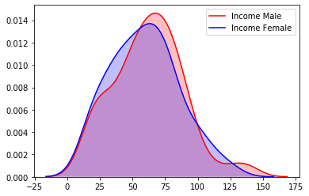

```python
p1=sns.kdeplot(df['Annual Income (k$)'].loc[df['Gender']=='Male'],label='Income Male', shade=True, color='r')
p1=sns.kdeplot(df['Annual Income (k$)'].loc[df['Gender']=='Female'], label='Income Female', shade=True, color='b')
plt.show()
```

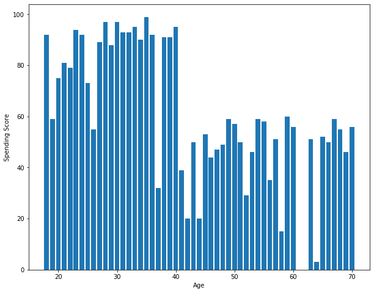

```python
df.sort_values(['Age'])
plt.figure(figsize=(10,8))
plt.bar(df['Age'], df['Spending Score (1-100)'])
#### the barchart here needs a y axis(scaler) to locate the "Value"
####it is not like bar_chart in R, the y axis not necessarily show "count" here in Py
plt.xlabel('Age')
plt.ylabel('Spending Score')
plt.show()
```

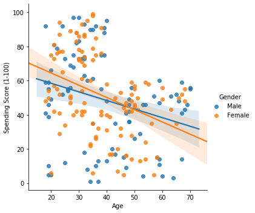

```python
sns.lmplot(x='Age', y='Spending Score (1-100)', data=df, fit_reg=True, hue='Gender')
plt.show()

##info: very small correlation, as the correlation plot showed!
```

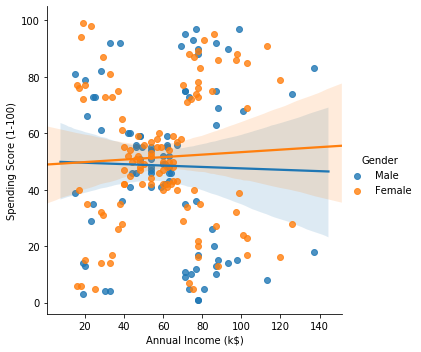

```python
sns.lmplot(x='Annual Income (k$)', y='Spending Score (1-100)', data= df, fit_reg=True, hue='Gender')
plt.show()
##info: This dataset is not real!!!
```

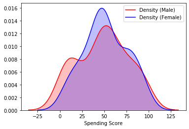

```python
color=['r','b']
for h,i in enumerate(set(df.Gender)):
    p1= sns.kdeplot(df['Spending Score (1-100)'].loc[df.Gender==i], label= 'Density ({})'.format(i), shade=True, color=color[h])

plt.xlabel('Spending Score')
plt.show()
```

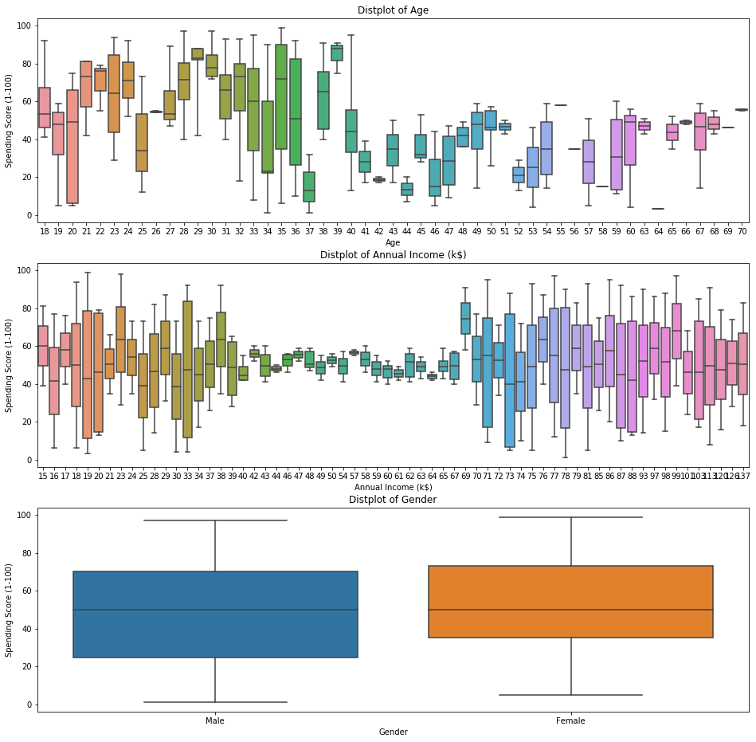

```python
plt.figure(1 , figsize = (16 , 16))
n = 0
for x in ['Age' , 'Annual Income (k$)' , 'Gender']:
    n += 1
    plt.subplot(3 , 1 , n)
    #### n is which subplot to draw
    sns.boxplot(x=x, y='Spending Score (1-100)', data=df, whis='range')
    #### x is a factor var now
    plt.title('Distplot of {}'.format(x))
```

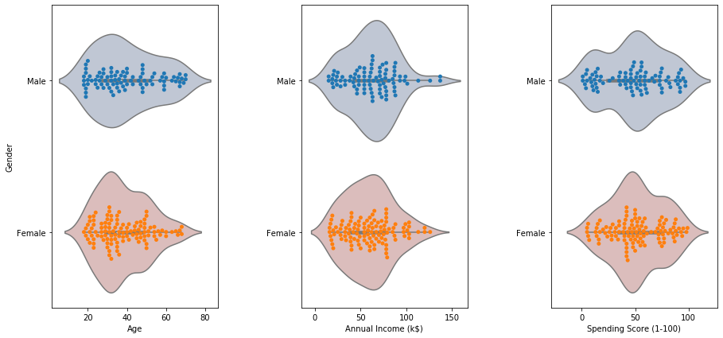

```python
#Violin Plot
plt.figure(figsize=(15,7))
n=0
x=df.columns[2:5]
for col in x:
    n+=1
    plt.subplot(1,3,n)
    plt.subplots_adjust(hspace=0.5, wspace=0.5)
    sns.violinplot(x=col, y='Gender', data=df, palette='vlag')
    sns.swarmplot(x=col, y='Gender', data=df)
    plt.ylabel('Gender' if n==1 else "")
plt.show()
```

# K-mean

```python
from sklearn.cluster import KMeans
```

```python
#df['Gender'].factorize()
#type(df['Gender'].factorize())
#type(df['Gender'].factorize()[0])
```

### Elbow plot

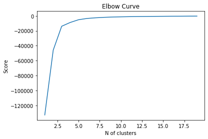

```python
y=df[['Spending Score (1-100)']].values
x=df[['Annual Income (k$)']].values
#### Kmeans needs 2d array, so here use 2 brackets!


Nc=range(1,20)
kmeans=[KMeans(n_clusters=i) for i in Nc ]
#### Create a Kmean machine with n_group
#### python 的邏輯都是“物件”, 因此都需要先創建“機器”
kmeans
score = [kmeans[i].fit(y).score(y) for i in range(len(kmeans))]
#### Opposite of the value of y on the K-means objective.
#### score 就是 內部距離 加負號！！！
score

plt.plot(Nc,score)
plt.xlabel('N of clusters')
plt.ylabel('Score')
plt.title('Elbow Curve')
plt.show()
```

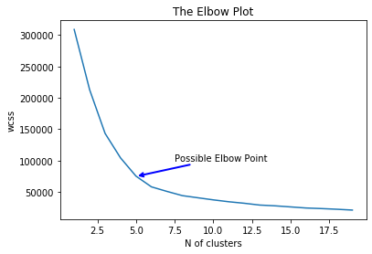

```python
#within-cluster sum of square
#kmeans.inertia_ = wcss
wcss = []

for i in range(1,20):
    kmeans=KMeans(n_clusters=i, init='k-means++', random_state=0)
    kmeans.fit(df.iloc[:,2:])
    wcss.append(kmeans.inertia_)

plt.plot(range(1,20), wcss)

plt.title('The Elbow Plot')
plt.xlabel('N of clusters')
plt.ylabel('wcss')
# Annotate arrow
plt.annotate('Possible Elbow Point', xy=(5,75000), xytext=(7.5,100000), xycoords='data',
             arrowprops=dict(arrowstyle = '->', connectionstyle = 'arc3', color='blue',lw=2))
plt.show()
```

##### see: https://scikit-learn.org/stable/modules/generated/sklearn.cluster.KMeans.html

### fit and predict

For unsupervised learning we use "fit_predict()" wherein for supervised learning we use "fit_tranform()"

```python
KMeans()

km = KMeans(n_clusters= 5, init='k-means++', random_state=0)
#### init:  Method for initialization
#### random_state, set a seed to make sure every time we run the model, we choose the same centeroid
clusters= km.fit_predict(df.iloc[:,2:5])

#### fit_predict(x) equals to fit(x).predict(x)
#### predict(): Predict the closest cluster each sample in X belongs to.
#### fit(obj) the obj can only contain 'Numerical'
df_l=df
df_l['label']=clusters
```

```python
####test random_state here

'''
for i in range(5):
    print(KMeans(n_clusters= 5, init='k-means++', random_state=0).fit(df.iloc[:,2:]).inertia_)

for i in range(5):
    print(KMeans(n_clusters= 5, init='k-means++', random_state=i).fit(df.iloc[:,2:]).inertia_)
'''
```

```
"\nfor i in range(5):\n    print(KMeans(n_clusters= 5, init='k-means++', random_state=0).fit(df.iloc[:,2:]).inertia_)\n\nfor i in range(5):\n    print(KMeans(n_clusters= 5, init='k-means++', random_state=i).fit(df.iloc[:,2:]).inertia_)\n"
```

### 2d scatterplot

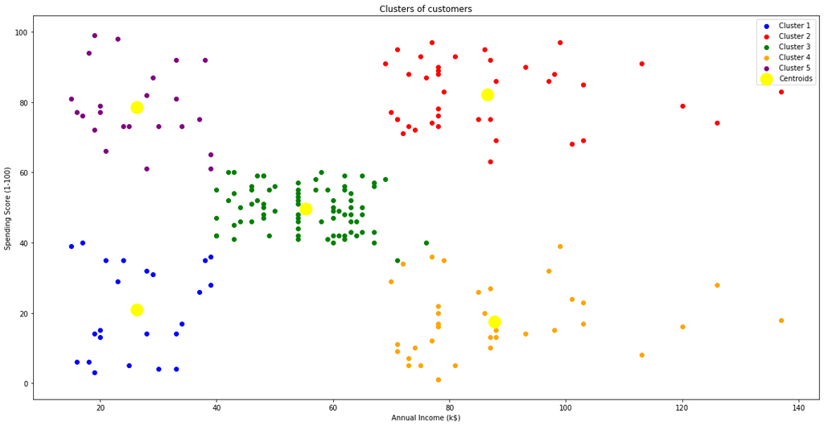

```python
color=['blue','red','green', 'orange', 'purple']

fig= plt.figure(figsize=(20,10))

for i in range(5):
    plt.scatter(df_l['Annual Income (k$)'][df_l.label==i], df_l['Spending Score (1-100)'][df_l.label==i], c=color[i], label = 'Cluster {}'.format(i+1))
## draw the centroid
##km.cluster_centers_

plt.scatter(km.cluster_centers_[:,1], km.cluster_centers_[:,2], s=300, c='yellow', label='Centroids')
#### the fitted KMeans machine has a attribute of centroid for each column and cluster!
#### s : how big the circle!
plt.title('Clusters of customers')
plt.xlabel('Annual Income (k$)')
plt.ylabel('Spending Score (1-100)')
plt.legend()
plt.show()
```

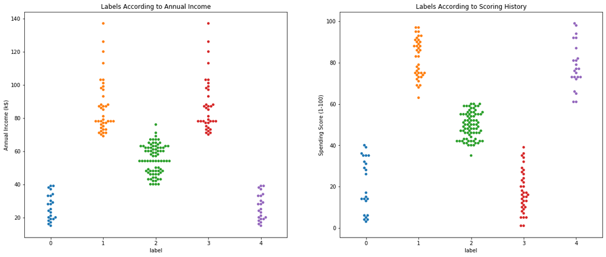

```python
f,ax=plt.subplots(1,2,figsize=(20,8))

sns.swarmplot(x='label',y='Annual Income (k$)' ,data=df_l, ax=ax[0])
#### swarmplot : Draw a categorical scatterplot with non-overlapping points.
ax[0].set_title('Labels According to Annual Income')

sns.swarmplot(x='label', y='Spending Score (1-100)', data=df_l, ax=ax[1])
ax[1].set_title('Labels According to Scoring History')
plt.show()
```

### 3d scatterplot

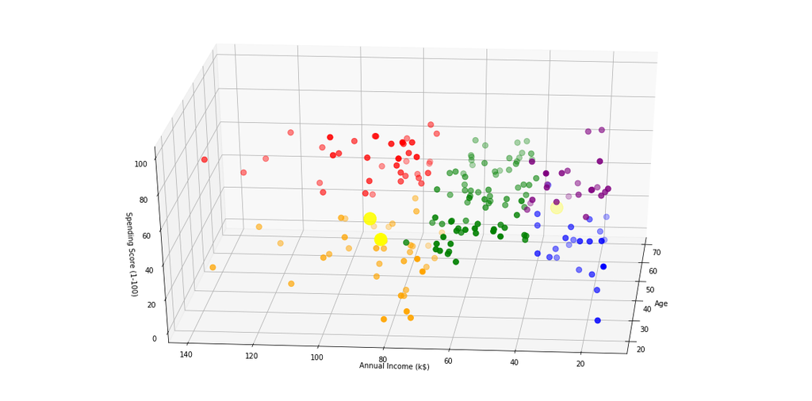

```python
from mpl_toolkits.mplot3d import Axes3D

color=['blue','red','green', 'orange', 'purple']

fig = plt.figure(figsize= (20,10))
ax= fig.add_subplot(111, projection='3d')
#### 3d 圖的邏輯是先將畫布設定為3d
for i in range(5):
    ax.scatter(df_l.Age[df_l.label==i], df_l['Annual Income (k$)'][df_l.label==i], df_l['Spending Score (1-100)'][df_l.label==i], c=color[i], s=60)
#### 然後再把每一個軸都填上去
#### 記住畫布是可以一層一層疊上去的
ax.scatter(km.cluster_centers_[0], km.cluster_centers_[1], km.cluster_centers_[2], s=300, c='yellow')
##????為什麼這邊只畫2軸？
ax.view_init(30,185)
#### 觀看角度
plt.xlabel("Age")
plt.ylabel("Annual Income (k$)")
ax.set_zlabel('Spending Score (1-100)')
plt.show()
```

# Hierachical Cluster with TSNE

```python
#Pre Processing, factorize
df_d = df.drop(['CustomerID'], axis=1)
df_d['Gender'] = df_d['Gender'].factorize()[0]
```

```python
from sklearn.manifold import TSNE
tsn= TSNE()
res_tsne = tsn.fit_transform(df_d)

from sklearn.cluster import AgglomerativeClustering as AggClus
clus_mod = AggClus(n_clusters= 5, linkage='ward')
#### create model
assign = clus_mod.fit_predict(df_d)
#### fit and predict, thus assign is the label dervied from Hierarchical model with ward method!
## or use assign= clus_mod.fit(df_d).labels_
```

##### TSNE exlaination:

```
TSNE: a dimensionality reduction method, like PCA, we can use it when have small sample with many dimension (Variables)
but NOT like PCA focusing on the Varianbility of data, TSNE focuses on the smilatrity.
Thus, TSNE is good at clustering.
```

Refference:

http://bit.ly/2N6tUof

http://bit.ly/2N0JLV1

https://distill.pub/2016/misread-tsne/

#### Difference between fit, transfrom, fit_transform:

https://blog.csdn.net/weixin_38278334/article/details/82971752

#### Agglomerative Explaination:

Agglomerative is a clustering mathod building a tree, the logic is that we decide how many clusters (leaf) we want to have and the algorithm uses the dmin, dmax or davg to create the the assigned number of clusters.

The Agglomerative Clustering class will require two inputs:

- n_clusters: The number of clusters to form as well as the number of centroids to generate.
- linkage: Which linkage criterion to use. The linkage criterion determines which distance to use between sets of observation. The algorithm will merge the pairs of cluster that minimize this criterion. Value will be: 'complete'

Note: It is recommended that try everything with 'average' as well

Refference: https://blog.csdn.net/Haiyang_Duan/article/details/77995665

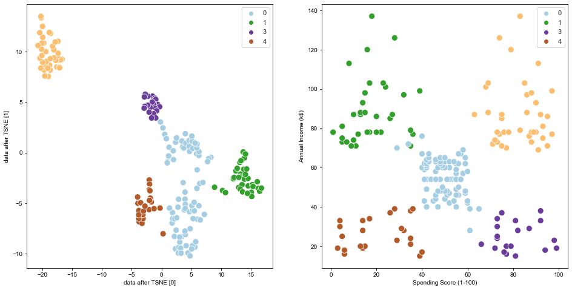

```python
##use two clustering methods, TSNE and Agglomerativ, to check the data

f,ax = plt.subplots(1,2,figsize=(16,8))
sns.set(style= 'whitegrid', palette= 'pastel')
cmap= sns.cubehelix_palette(dark = .5, light= .5, as_cmap=True)
sns.scatterplot(x=res_tsne[:,0], y=res_tsne[:,1], s=100, hue=assign, palette='Paired', ax=ax[0])
####x,y is the value after data being TSNE, color is the label that hierarchical model predict
ax[0].set_xlabel('data after TSNE [0]')
ax[0].set_ylabel('data after TSNE [1]')

plt.figure(figsize=(8,8))
sns.scatterplot(data=df_d, x= df_d['Spending Score (1-100)'], y= df_d['Annual Income (k$)'],
                hue=assign, palette= 'Paired', s=100, ax=ax[1])
#### x,y is the original value of Spending and Income, color is the label that hierarchical model predict


plt.show()
```

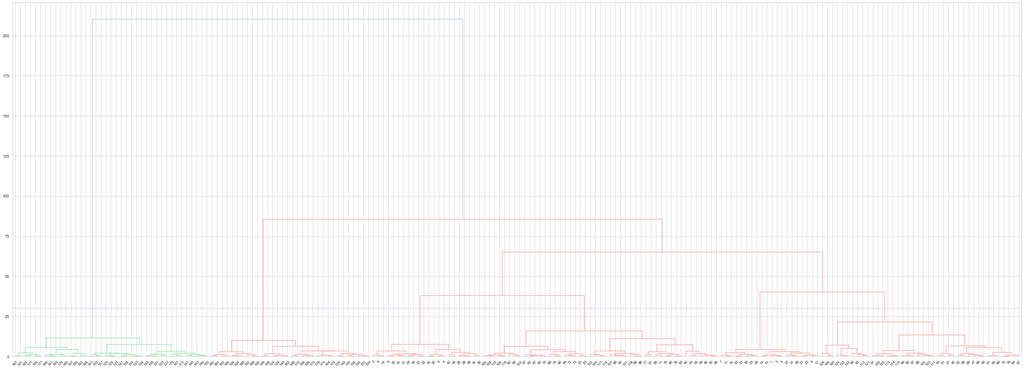

```python
## We previously finished dimension reduction to reduce 4 dimensions to 2 dimesions

from scipy.cluster.hierarchy import dendrogram, ward
##sns.set(style='whitegrid')


link= ward(res_tsne)
plt.figure(figsize=(50,18))
#### calculate the distance between each data point using ward method
dendrogram(link,leaf_rotation= 45, leaf_font_size= 10)

ax = plt.gca()
bounds = ax.get_xbound()
ax.plot(bounds, [30,30], '--', c='m')
####??????
####plt.plot(): Plot y versus x as lines and/or markers.
#### [30,30] means that the line's starting and ending points are both at y axis's 30

plt.show()
#### here, the y axis is the distance(derived from ward linkage), x axis is observance idx
```

```python
## Distance matricx

from scipy.spatial import distance_matrix

dist = distance_matrix(df_d,df_d)
#### compute distance between each point
print(dist)
```

```
[[  0.          42.23742416  33.04542328 ... 117.11532778 124.51104369
  130.16143822]
 [ 42.23742416   0.          75.12655988 ... 111.80339887 137.74977314
  122.38463956]
 [ 33.04542328  75.12655988   0.         ... 129.88456413 122.22520198
  143.77760604]
 ...
 [117.11532778 111.80339887 129.88456413 ...   0.          57.10516614
   14.35270009]
 [124.51104369 137.74977314 122.22520198 ...  57.10516614   0.
   65.06150936]
 [130.16143822 122.38463956 143.77760604 ...  14.35270009  65.06150936
    0.        ]]
```

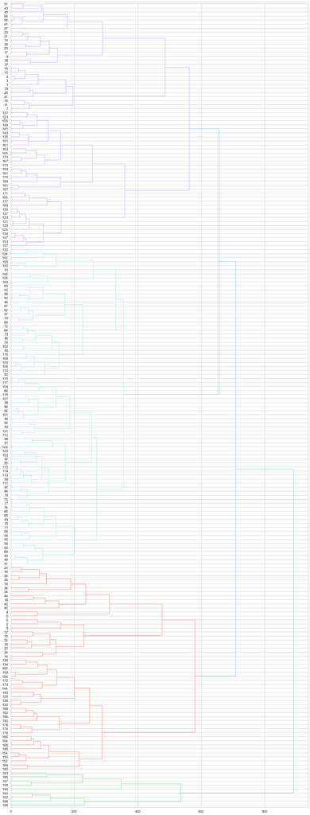

```python
from scipy.cluster.hierarchy import linkage

link= linkage(dist, 'complete')
#### using compelete method to do hierarchy clustering

plt.figure(figsize=(18,50))
dendrogram(link, leaf_rotation= 0, leaf_font_size= 12, orientation= 'right')

plt.show()
```

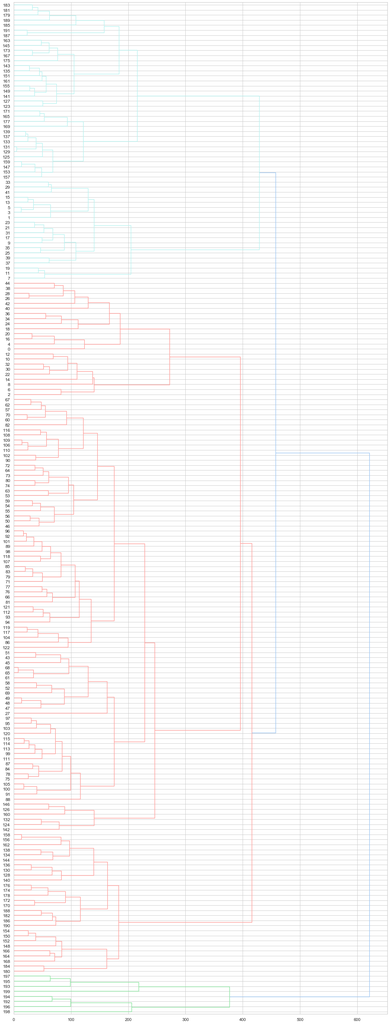

```python
link= linkage(dist, 'average')
plt.figure(figsize=(18,50))
dendrogram(link, leaf_rotation= 0, leaf_font_size= 12, orientation='right')
plt.show()
```

#### Hierarchy, ward linkage explaination

http://mirlab.org/jang/books/dcpr/dcHierClustering.asp?title=3-2%20Hierarchical%20Clustering%20(%B6%A5%BCh%A6%A1%A4%C0%B8s%AAk)&language=chinese

```
(Text(0, 0.5, 'Spending Score (1-100)'), Text(0.5, 0, 'Age'))
```

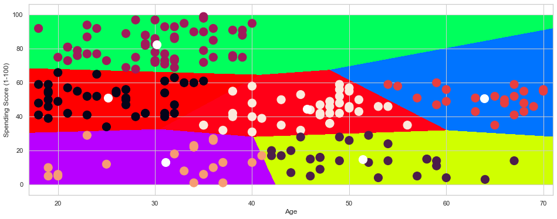

```python
X1 = df[['Age' , 'Spending Score (1-100)']].iloc[: , :].values
inertia = []
for n in range(1 , 7):
    algorithm = (KMeans(n_clusters = n ,init='k-means++', n_init = 6 ,max_iter=300,
                        tol=0.0001,  random_state= 101  , algorithm='elkan') )
    algorithm.fit(X1)
    inertia.append(algorithm.inertia_)


algorithm = (KMeans(n_clusters = 6 ,init='k-means++', n_init = 6 ,max_iter=300,
                        tol=0.0001,  random_state= 111  , algorithm='elkan') )
algorithm.fit(X1)
labels1 = algorithm.labels_
centroids1 = algorithm.cluster_centers_

h = 0.02
x_min, x_max = X1[:, 0].min() - 1, X1[:, 0].max() + 1
y_min, y_max = X1[:, 1].min() - 1, X1[:, 1].max() + 1
xx, yy = np.meshgrid(np.arange(x_min, x_max, h), np.arange(y_min, y_max, h))
Z = algorithm.predict(np.c_[xx.ravel(), yy.ravel()])

plt.figure(1 , figsize = (16 , 6) )
plt.clf()
Z = Z.reshape(xx.shape)
plt.imshow(Z , interpolation='nearest',
           extent=(xx.min(), xx.max(), yy.min(), yy.max()),
           cmap = plt.cm.hsv, aspect = 'auto', origin='lower')

plt.scatter( x = 'Age' ,y = 'Spending Score (1-100)' , data = df , c = labels1 ,
            s = 200 )
plt.scatter(x = centroids1[: , 0] , y =  centroids1[: , 1] , s = 200 , c = 'w' )
plt.ylabel('Spending Score (1-100)') , plt.xlabel('Age')
```

```
(Text(0, 0.5, 'Spending Score (1-100)'), Text(0.5, 0, 'Annual Income (k$)'))
```

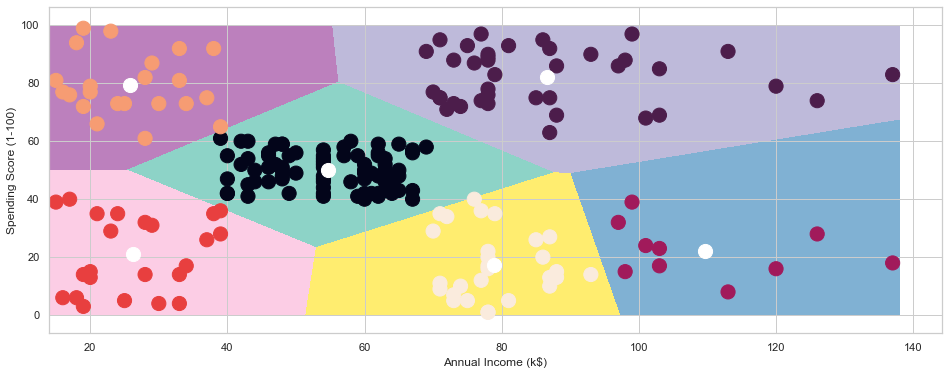

```python
X2 = df[['Annual Income (k$)' , 'Spending Score (1-100)']].iloc[: , :].values
inertia = []
for n in range(1 , 7):
    algorithm = (KMeans(n_clusters = n ,init='k-means++', n_init = 6 ,max_iter=300,
                        tol=0.0001,  random_state= 101  , algorithm='elkan') )
    algorithm.fit(X2)
    inertia.append(algorithm.inertia_)


algorithm = (KMeans(n_clusters = 6 ,init='k-means++', n_init = 6 ,max_iter=300,
                        tol=0.0001,  random_state= 101  , algorithm='elkan') )
algorithm.fit(X2)
labels2 = algorithm.labels_
centroids2 = algorithm.cluster_centers_


h = 0.02
x_min, x_max = X2[:, 0].min() - 1, X2[:, 0].max() + 1
y_min, y_max = X2[:, 1].min() - 1, X2[:, 1].max() + 1
xx, yy = np.meshgrid(np.arange(x_min, x_max, h), np.arange(y_min, y_max, h))
Z2 = algorithm.predict(np.c_[xx.ravel(), yy.ravel()])

plt.figure(1 , figsize = (16 , 6) )
plt.clf()
Z2 = Z2.reshape(xx.shape)
plt.imshow(Z2 , interpolation='nearest',
           extent=(xx.min(), xx.max(), yy.min(), yy.max()),
           cmap = plt.cm.Set3, aspect = 'auto', origin='lower')

plt.scatter( x = 'Annual Income (k$)' ,y = 'Spending Score (1-100)' , data = df , c = labels2 ,
            s = 200 )
plt.scatter(x = centroids2[: , 0] , y =  centroids2[: , 1] , s = 200 , c = 'w' )
plt.ylabel('Spending Score (1-100)') , plt.xlabel('Annual Income (k$)')
```

# Density Based Clustering (DBSCAN)

Most of the traditional clustering techniques, such as k-means, hierarchical and fuzzy clustering, can be used to group data without supervision.

However, when applied to tasks with arbitrary shape clusters, or clusters within cluster, the traditional techniques might be unable to achieve good results. That is, elements in the same cluster might not share enough similarity or the performance may be poor. Additionally, Density-based Clustering locates regions of high density that are separated from one another by regions of low density. Density, in this context, is defined as the number of points within a specified radius.

In this part, the main focus will be manipulating the data and properties of DBSCAN and observing the resulting clustering.

Modeling DBSCAN stands for Density-Based Spatial Clustering of Applications with Noise. This technique is one of the most common clustering algorithms which works based on density of object. The whole idea is that if a particular point belongs to a cluster, it should be near to lots of other points in that cluster.

It works based on two parameters: Epsilon and Minimum Points

- Epsilon determine a specified radius that if includes enough number of points within, we call it dense area
- minimumSamples determine the minimum number of data points we want in a neighborhood to define a cluster.

#### 理解： 在多維平面上畫一個點，指定Epsilon(圓周), minimumSamples(密度)，看看有多少observation符合這個設定，就是同一個cluster

refference: https://zh.wikipedia.org/wiki/DBSCAN

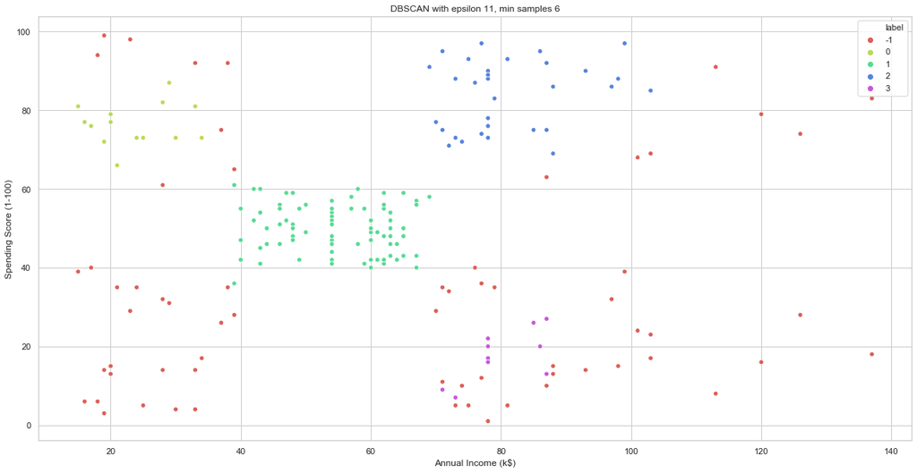

```python
from sklearn.cluster import DBSCAN

plt.figure(figsize=(20,10))

db= DBSCAN(eps= 11, min_samples= 6).fit(df_d)
df_l_DBSCAN = df_d
df_l_DBSCAN.label= db.labels_

sns.scatterplot(df_l_DBSCAN['Annual Income (k$)'], df_l_DBSCAN['Spending Score (1-100)'], hue=df_l_DBSCAN['label'],
                palette= sns.color_palette('hls',np.unique(db.labels_).shape[0]))
plt.title('DBSCAN with epsilon 11, min samples 6')
plt.show()
```

#### Interpretation

The model did not work well  
The Label -1 means outliers so it will appear most as outliers. We may have performed better if we had had a bigger data.

# Mean Shift Algorithm

MeanShift clustering aims to discover blobs in a smooth density of samples. It is a centroid based algorithm, which works by updating candidates for centroids to be the mean of the points within a given region. These candidates are then filtered in a post-processing stage to eliminate near-duplicates to form the final set of centroids.

The algorithm automatically sets the number of clusters, instead of relying on a parameter bandwidth, which dictates the size of the region to search through. This parameter can be set manually, but can be estimated using the provided estimate_bandwidth function, which is called if the bandwidth is not set.

refference: https://www.youtube.com/watch?v=Evc53OaDTFc

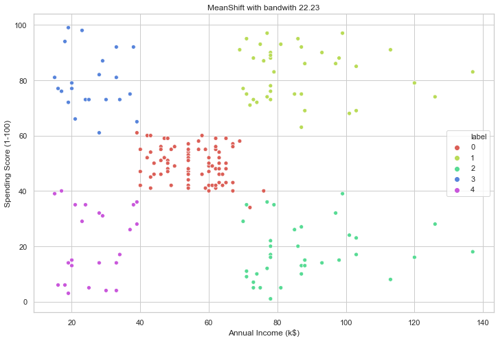

```python
from sklearn.cluster import MeanShift, estimate_bandwidth

bandwidth = estimate_bandwidth(df_d, quantile= 0.1)
#### let algorithm help us to find a good bandwidth
ms=MeanShift(bandwidth).fit(df_d)

df_l_ms = df_d
df_l_ms.label= ms.labels_

plt.figure(figsize=(12,8))
sns.scatterplot(df_l_ms['Annual Income (k$)'], df_l_ms['Spending Score (1-100)'], hue= df_l_ms.label,
               palette= sns.color_palette('hls', np.unique(ms.labels_).shape[0]))
plt.title('MeanShift with bandwith {}'.format(round(bandwidth,2)))
plt.show()
```

# Wrap Up All in One Place

Let's visualize all the algorithms we used so far and see their clustering distributions.

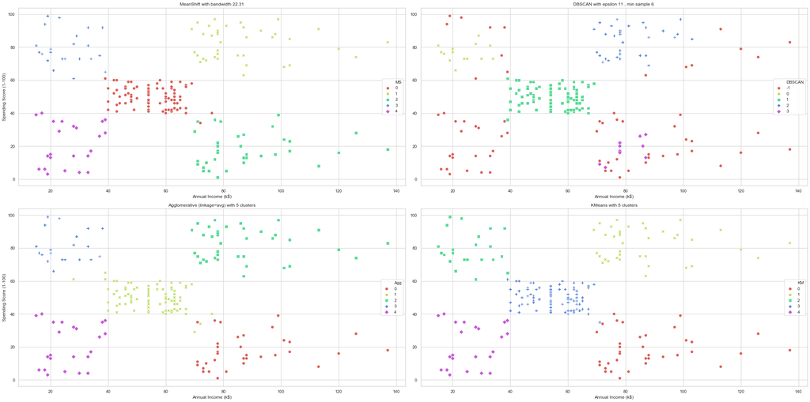

```python
plt.clf()
fig= plt.figure(figsize=(30,15))
algorithms= ['KMeans', 'Agglomerative (linkage=avg)', 'DBSCAN', 'MeanShift']
DBSCAN_Parm=(11,6)
bandwidth = estimate_bandwidth(df_d, quantile=0.1)

df_wrap=df_d
####fit_predict(df)= fit(df).label_
df_wrap['KM']= KMeans(n_clusters=5).fit_predict(df_d)
df_wrap['Agg']= AggClus(n_clusters=5, linkage='average').fit_predict(df_d)
df_wrap['DBSCAN']= DBSCAN(eps=DBSCAN_Parm[0], min_samples=DBSCAN_Parm[1]).fit_predict(df_d)
df_wrap['MS']= MeanShift(estimate_bandwidth(df_d, quantile=0.1)).fit_predict(df_d)



for i in (1,2,3,4):
    ax= fig.add_subplot(i+220)
    sns.scatterplot(df_wrap['Annual Income (k$)'], df_wrap['Spending Score (1-100)'],
                    hue=df_wrap.iloc[:,-i],style= df_wrap.iloc[:,-i],
                    palette= sns.color_palette('hls',np.unique(df_wrap.iloc[:,-i]).shape[0]),s=60, ax=ax)
    if df_wrap.columns[-i] =='DBSCAN' :
        ax.set_title('DBSCAN with epsilon {} , min sample {} '.format(DBSCAN_Parm[0],DBSCAN_Parm[1]))
    elif df_wrap.columns[-i]=='MS':
        ax.set_title('MeanShift with bandwidth {}'.format(round(bandwidth,2)))
    else:
        ax.set_title('{} with {} clusters'.format(algorithms[-i], np.unique(df_wrap.iloc[:,-i]).shape[0]))
    plt.ylabel('Spending Score (1-100)' if i%2 !=0 else"")

plt.tight_layout()
plt.show()
```

```python
'''
##Another way for roop

plt.clf()
fig= plt.figure(figsize=(30,15))

n=0

for i in (1,2,3,4):
    n+=1
    plt.subplot(2,2,n)
    ##difference is the way of indexing subplot
    sns.scatterplot(df_wrap['Annual Income (k$)'], df_wrap['Spending Score (1-100)'],
                    hue=df_wrap.iloc[:,-i],style= df_wrap.iloc[:,-i],
                    palette= sns.color_palette('hls',np.unique(df_wrap.iloc[:,-i]).shape[0]),s=60)

    if df_wrap.columns[-i] =='DBSCAN' :
        plt.title('DBSCAN with epsilon {} , min sample {} '.format(DBSCAN_Parm[0],DBSCAN_Parm[1]))
    elif df_wrap.columns[-i]=='MS':
        plt.title('MeanShift with bandwidth {}'.format(round(bandwidth,2)))
    else:
        plt.title('{} with {} clusters'.format(algorithms[-i], np.unique(df_wrap.iloc[:,-i]).shape[0]))
    plt.xlabel('Annual Income (k$)' if i%2 !=0 else"")
    plt.ylabel('Spending Score (1-100)' if i%2 !=0 else"")

plt.tight_layout()
plt.show()

'''
```

```
'\n##Another way for roop\n\nplt.clf()\nfig= plt.figure(figsize=(30,15))\n\nn=0\n\nfor i in (1,2,3,4):\n    n+=1\n    plt.subplot(2,2,n)\n    ##difference is the way of indexing subplot\n    sns.scatterplot(df_wrap[\'Annual Income (k$)\'], df_wrap[\'Spending Score (1-100)\'],\n                    hu…
```

#### ALL clustering algorithms in sklearn : https://scikit-learn.org/stable/modules/clustering.html